# Design patterns

## Why do we need them ?

[Design Patterns: Elements of Reusable Object-Oriented Software](http://www.amazon.com/Design-Patterns-Elements-Reusable-Object-Oriented/dp/0201633612) by E. Gamma, R. Helm, R. Johnson and J. Vlissides (**the gang of four**)

- Designing object oriented code is hard
- designing **reusable** object-oriented software **is even harder**!

[figure not shown]

## Code Design $=$ **decomposition into objects**

- Some objects have real world counterparts (*e.g.* objects of type planet)
- others don't (*e.g.* array, matrices, streams).

## Design requirements

- Solution specific to a problem
- General enough to address future problems
- Performance Issues
- Avoid/Minimize re-design
- Vocabulary for design ideas
- Minimize costs (development time)

## Reuse solutions

- Object-oriented organisation repeat patterns

The design patterns

- Knowing the patterns $\Rightarrow$ quick application to your problems
- Help to produce more reusable systems
- Design patterns names $\Rightarrow$ vocabulary for team work

[figure not shown]

Motto: Designing for change

## Design patterns: What they are

Design patterns have four essential elements:

- **Pattern name**: associates problem with solutions&consequences  
  $\Rightarrow$ Improves communication and documentation
- **Problem**: Scenario/conditions of when to apply a pattern
- **Solution**: Description of the arrangement of classes and objects
- **Consequences**: Results and trade-offs. (allows to know design alternatives)

## Remarks

- The appropriate design pattern depends on the programming language.
- Several design patterns are often combined together

## Design patterns pros&cons

- Pros:
  - consider/evaluate different design solutions
  - easier understanding of existing code (matching patterns)
  - easier start of a project (using general design patterns)
- Cons:
  - Strictly applying design patterns reduces creativity
  - Standard solutions may not be applied (scientific programming is complex)
    - New cases = new (more complex) solutions
    - In high performance computing: optimization is a strong constraint

Design patterns  
A useful source of inspiration  
but no bible!

# Design patterns examples

- Present three important design patterns
- Apply/recognize these patterns for our particle's code
- Description of these examples
- a larger catalog of design patterns in [Design Patterns: Elements of Reusable Object-Oriented Software](http://www.amazon.com/Design-Patterns-Elements-Reusable-Object-Oriented/dp/0201633612)

## *Iterator*

- *General description*: Gives access to elements of a container without exposing its internal representation
- Our problem (Particles):
  - Particles stored in an container
  - Perform computations/IOs on the particles
  - Traverse the container in different(random) ways
  - Access elements without knowing the internal structure of the container (list, vector, set, ...)

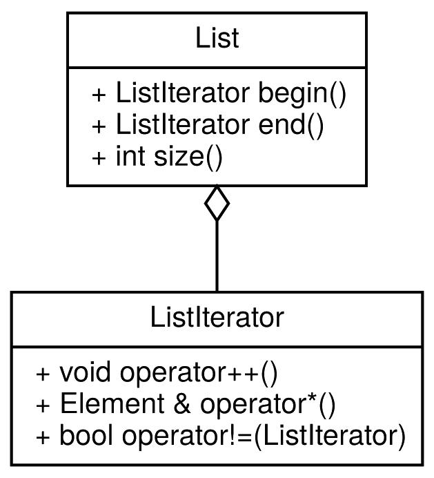

```
struct List {
  using Element = Planet;

  // define a sub type
  struct ListIterator;

  int size();
  ListIterator begin();
  ListIterator end();
};

struct List::ListIterator {
  Element &operator*();
  void operator++();
  bool operator!=(ListIterator &e);
};
```

```
struct List {
  struct ListIterator;

  int size();
  void add(Element e) { container.push_back(e); };

  ListIterator begin();
  ListIterator end();

private:
  std::vector<Element> container;
};

struct List::ListIterator {

  ListIterator(Element &current) { this->ptr = &current; }
  Element &operator*() { return *this->ptr; };
  void operator++() { ++this->ptr; };
  bool operator!=(ListIterator e) { return e.ptr != this->ptr; };

private:
  Element *ptr;
};

List::ListIterator List::begin() { return ListIterator(this->container[0]); };
List::ListIterator List::end() {
  return ListIterator(this->container[this->size()]);
};

int main() {
  int p1 = 1;

  List list;

  for (auto &&v : list) {
    std::cout << v << std::endl;
  }
}
```

- Consequences:
  - Standardize container's interface
  - Can vary how to traverse a container (different iterator types)
  - Concurrent traversal of a container (double loop)

```
  List list;

  for (auto &&v : list) {
    std::cout << v << std::endl;
  }
```

## *Singleton*

- General description: Ensure that a class has only one instance, and provides a global point of access
- Our problem (Particles):
  - Only one container of particles
  - Uniqueness enforced by the container himself
  - Access the container of particles from everywhere (global)
  - Contain planets or ping-pong balls (polymorphic)

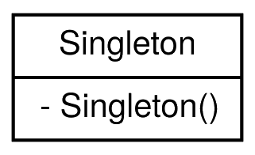

```
class Singleton {

private:
  Singleton();

  friend Singleton &get();
};
```

```
Singleton *unique_instance = nullptr; // no encapsulation

Singleton &get() { // not part of Singleton::
  if (unique_instance == nullptr)
    unique_instance = new Singleton();

  return *unique_instance;
}
```

## Static members and static members (C++)

- static variable/member is a unique and permanent variable

```
class A {
public:
  static int a;
};

int A::a = 1;
```

- what happens when we do this ? and why ?

```
  A a1;
  A a2;

  a1.a = 2; // also modifies a2.a
```

- static method applies with no instance

```
class B {

public:
  static int foo();
};
```

```
  // do not need an instance to be called
  B::foo();
```

## Static members and static members (python)

```
class A:
    # in the scope of the class
    a = 1

    def __init__(self):
        pass


a1 = A()
a2 = A()

a1.a = 2 # also modifies a2.a
```

- static method applies with no instance

```
class B :

    @staticmethod
    def foo(cls):
        print(cls)


# do not need an instance to be called
B.foo()
```

## *Singleton* generic solution

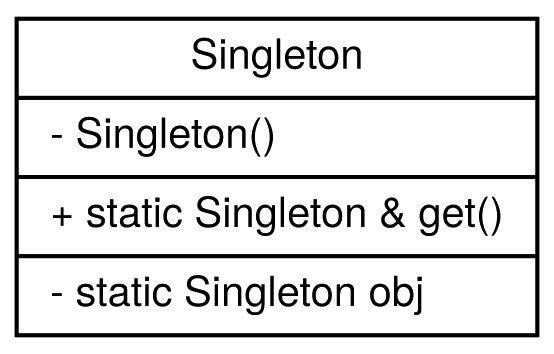

- Consequences:
  - controlled creation of the unique instance
  - Transverse/global access to instance (with class name)
  - Polymorphic behavior

```
struct Particles {
  static Particles &get();

private:
  Particles();
  static Particles obj;
};

struct Planets : public Particles {
  static Particles &get();
};
```

```
  Particles &obj = Planets::get();    // creation
  Particles &obj2 = Particles::get(); // access
```

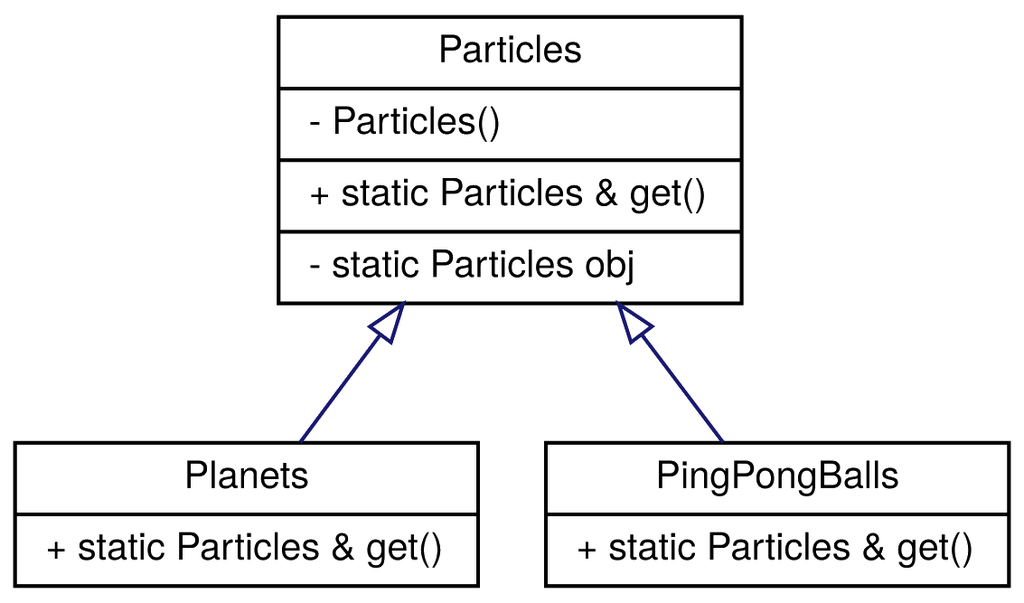

## *Abstract Factory*

- General description: Provides an interface for creating dependent/coherent objects without specifying their concrete classes.
- Our problem (Particles)
  - Particles code working for various particle types
  - A run deals with a single particle type
  - Other objects (IO, Compute) must be matching the (unique) particle type
  - "Automatic" creation of all the objects
- Abstract Factory
  - The system is independent of how the objects are created/composed
  - Related objects are designed to be used together: needs to be enforced
  - Objects are polymorphic (manipulated by interface)

### Example with Series

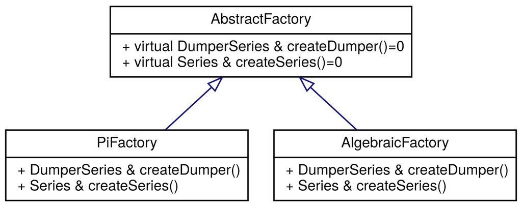

- Consequences:
  - Isolating concrete/daughter classes
  - Creating packages of objects made easy
  - Promotes consistency among objects
  - Supporting new kinds of objects is difficult (modify the creation routines)